```python
%matplotlib inline
import numpy as np
import matplotlib
import matplotlib.pyplot as plt
import scipy
from scipy import stats
from matplotlib import pylab
from pylab import *

# import library
import pickle
import pandas

plt.rcParams["figure.figsize"] = (10,4)
```

```python
# open the file of interest, and use pickle loading
infile = open ("qcd_100000_pt_250_500.pkl",'rb')
qcd_dict = pickle.load(infile)
higgsfile = open("higgs_100000_pt_250_500.pkl",'rb')
higgs_dict = pickle.load(higgsfile)

# list all keys of the files
print(qcd_dict.keys())
print(higgs_dict.keys())
keys = qcd_dict.keys()

#open pseudoexperiment
pseudoexphigh = pandas.read_hdf("data_highLumi_pt_250_500.h5")
pseudoexplow = pandas.read_hdf("data_lowLumi_pt_250_500.h5")
```

```
Index(['pt', 'eta', 'phi', 'mass', 'ee2', 'ee3', 'd2', 'angularity', 't1',
       't2', 't3', 't21', 't32', 'KtDeltaR'],
      dtype='object')
Index(['pt', 'eta', 'phi', 'mass', 'ee2', 'ee3', 'd2', 'angularity', 't1',
       't2', 't3', 't21', 't32', 'KtDeltaR'],
      dtype='object')
```

# Lab 8 draft

In this lab we take a prelimiary look at simulated Large Hadron Collider (LHC) data which might arise in a search for the Higgs boson. In particular, we are concerned with signals that result from a Higgs boson decaying into a bottom quark/anti-quark pair, at a center-of-mass energy $\sqrt{s} = 13 TeV$.

The simulation data was provided by A. Schuy at University of Washington (2019).

Let us briefly descrbie the experimental setup and the resulting data. Two protons are accelerated until their center of mass energy is $13 TeV$. They are then collided into one another. This collision results in new particles that then go on to decay to particles of smaller mass, which may then go on to decay themselves (and so on). This results in 'jets' of subparticles. The Higgs decay into the bottom quark/anti-quark pair has a distinctive signature: the bottom quarks are relatively long lived, so our detectors will see what looks like two distinct jets.

LHC detectors and software work together to identify what might be a Higgs event; software then pieces together information about the original collision, which is what we deal with below.

Our background consists of QCD background contamination.

## Explanation of Variables

Below we display a table of our variables:

| Variable | Symbol | Meaning |
| --- | --- | --- |
| pt | $p_{t}$ | Transverse Momentum |
| eta | $\eta$ | Pseudopolarity |
| phi | $\phi$ | Azimuthal Angle |
| mass | m | Invariant mass |
| ee2 | $e_{2}$ | 2-Point Energy Correlation Function (ECF) ratio |
| ee3 | $e_{3}$ | 3-Point ECF ratio |
| d2 | $D_{2}$ | 3-to-2 Point ECF ratio |
| angularity | $\tau_{-2}$ |  |
| ktDeltaR | $k_{t}\Delta R$ |  |

The transverse (xy-plane) momentum refers to the momentum carried away from the collision site by the particle of interest (Higgs).

The pseudorapidity is given by the formula: $$\eta = -ln[tan(\frac{\theta}{2})]$$ where $\theta$ is the particle three-momentum and the proton beam axis.

The energy correlation functions are observables that special software optimize to probe the substructure of jets. They are defined by: $$e_{2}^{\beta} = \sum_{1\leq i < j \leq n_J} z_i z_j \theta_{ij}^\beta$$ $$e_{3}^{\beta} = \sum_{1\leq i < j < k \leq n_J} z_i z_j z_k \theta_{ij}^\beta \theta_{jk}^\beta \theta_{ik}^\beta$$ where $n_J$ is the number of particles in the jet. For more information see:

*Moult, Ian, Lina Necib, and Jesse Thaler. “New Angles on Energy Correlation Functions.” Journal of High Energy Physics 2016.12 (2016): n. pag. Crossref. Web.*

Below we display the histograms of data. Note that the plots labeled *QCD* refer to the background, while the plots labeled *Higgs* refer to the simulated signal:

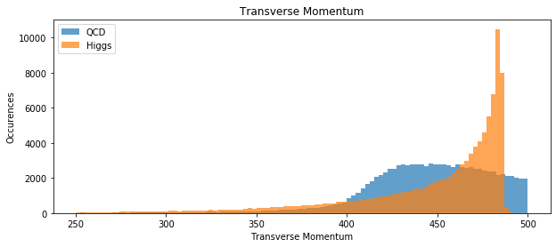

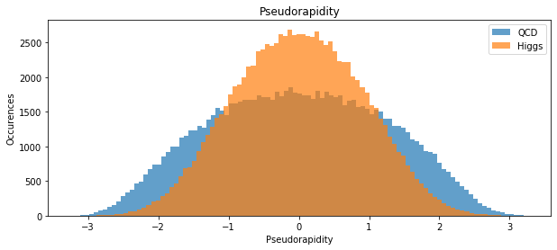

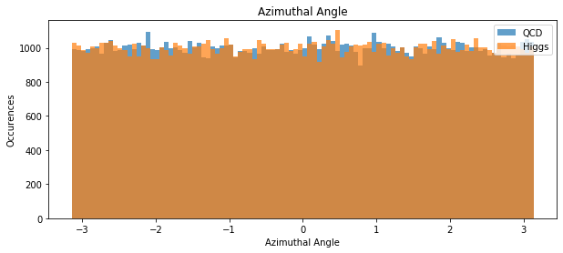

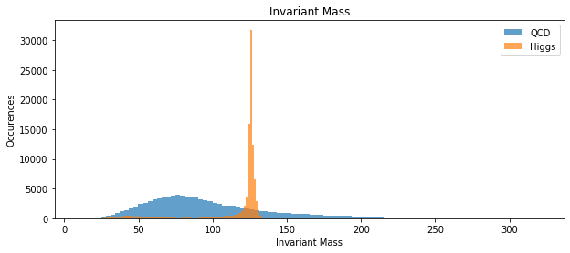

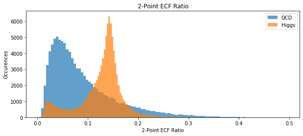

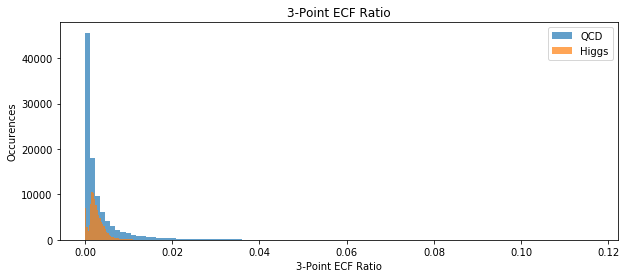

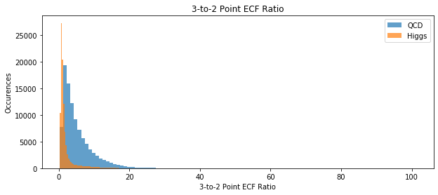

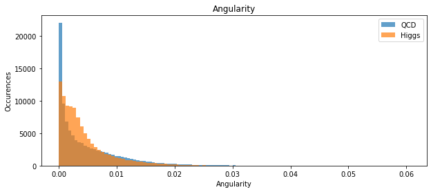

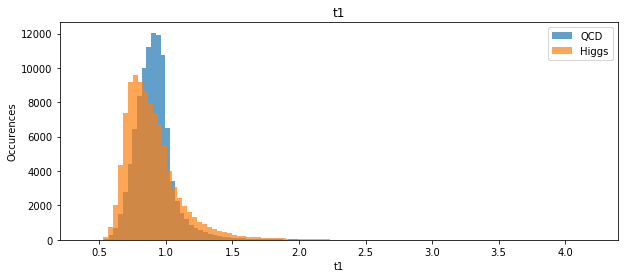

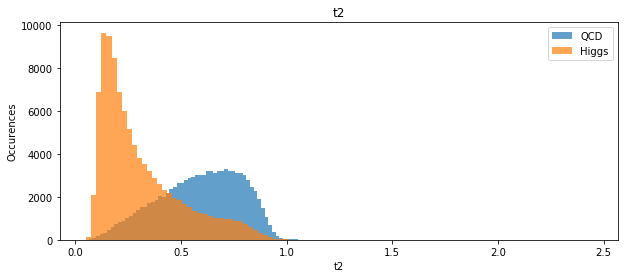

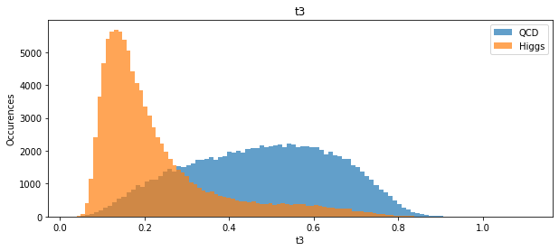

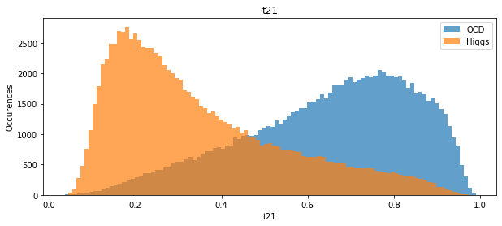

[2 more figures not shown]

```python
titles = ['Transverse Momentum','Pseudorapidity','Azimuthal Angle','Invariant Mass',
          '2-Point ECF Ratio','3-Point ECF Ratio','3-to-2 Point ECF Ratio',
         'Angularity','t1','t2','t3','t21','t32','ktDeltaR']

j = 0
for i in keys:
    qcd = qcd_dict[i]
    higgs = higgs_dict[i]
    figure()
    plt.title(titles[j])
    plt.xlabel(titles[j])
    plt.ylabel('Occurences')
    plt.hist(qcd,100,label = 'QCD',alpha = 0.7)
    plt.hist(higgs,100,label = 'Higgs',alpha = 0.7)
    plt.legend()
    j = j+1

plt.show()
```

Below we display the logplots of the above figures:

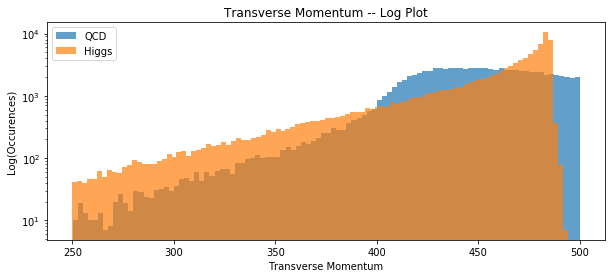

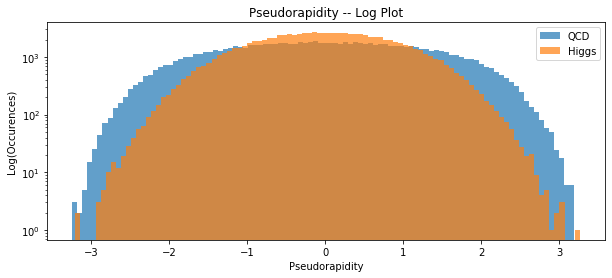

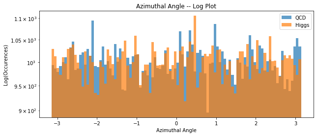

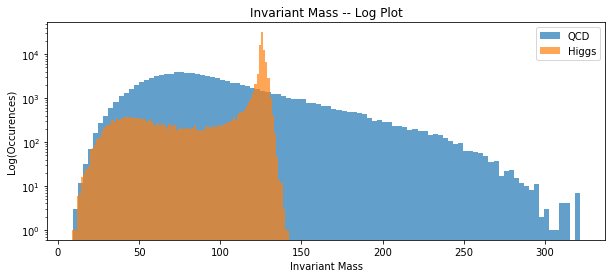

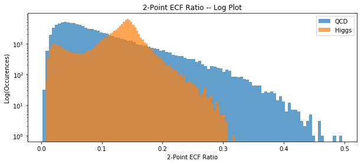

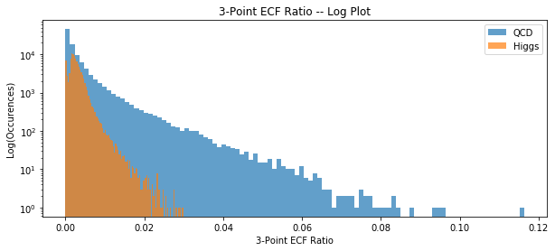

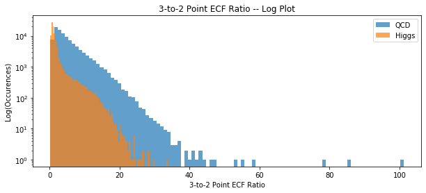

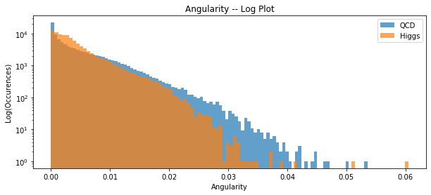

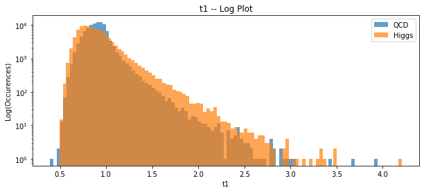

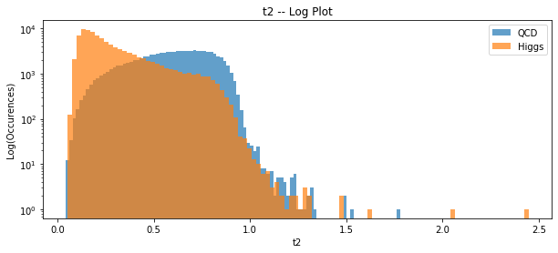

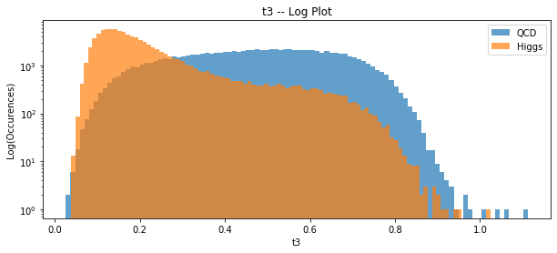

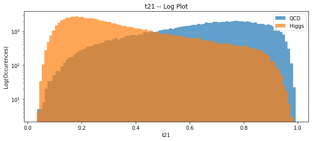

[2 more figures not shown]

```python
j = 0
for i in keys:
    qcd = qcd_dict[i]
    higgs = higgs_dict[i]
    figure()
    plt.title(titles[j] + ' -- Log Plot')
    plt.xlabel(titles[j])
    plt.ylabel('Log(Occurences)')
    plt.hist(qcd,100,label = 'QCD',alpha = 0.7)
    plt.hist(higgs,100,label = 'Higgs',alpha = 0.7)
    plt.legend()
    plt.yscale('log')
    j = j+1

plt.show()
```

The variables that seem to stand out as having signal distributions that may be separated from the background are transverse momentum, pseudorapitidy, invariant mass, 2-point ECF ratio, and ktDeltaR.

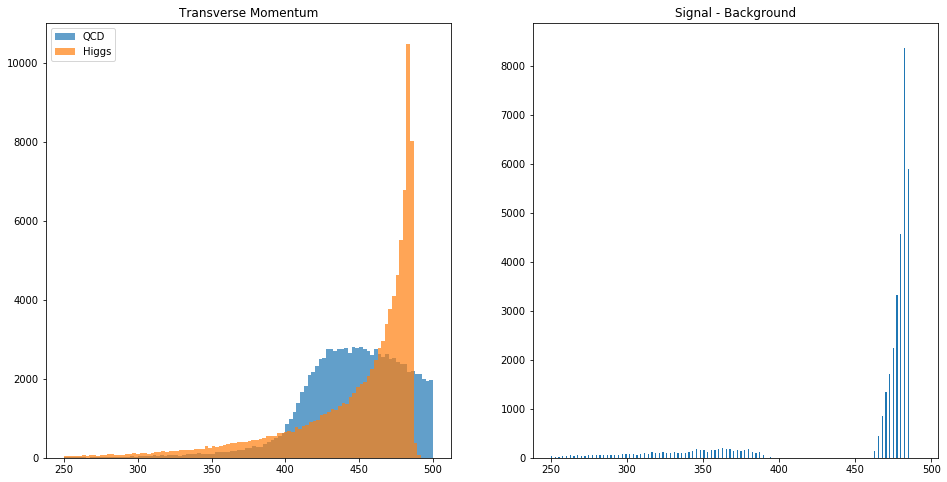

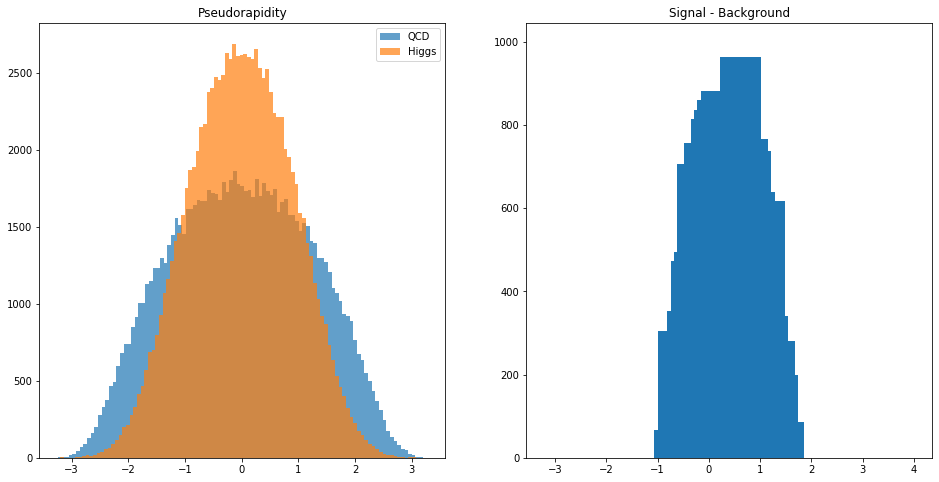

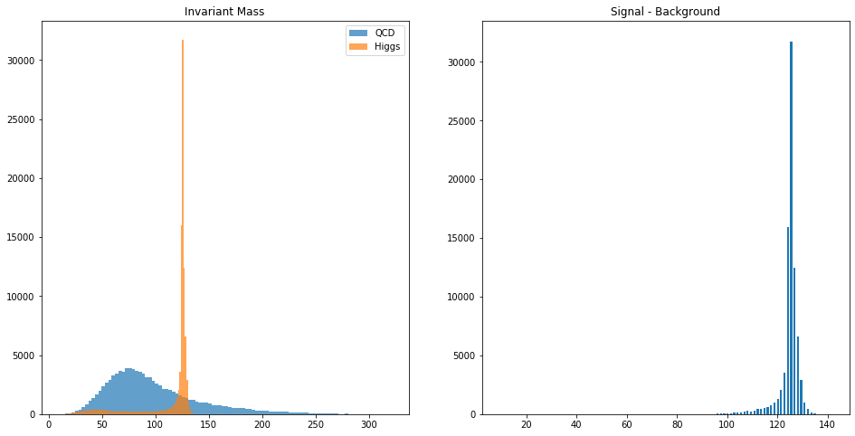

```python
fewerkeys = ['pt','eta','mass']
fewertitles = ['Transverse Momentum','Pseudorapidity','Invariant Mass']
j = 0
for i in fewerkeys:
    qcd = qcd_dict[i]
    higgs = higgs_dict[i]
    qcdhist,bins1 = np.histogram(qcd_dict[i],100)
    higgshist,bins2 = np.histogram(higgs_dict[i],100)
    bins1 = np.delete(bins1,100)
    bins2 = np.delete(bins2,100)
    differences = higgshist - qcdhist

    fig, ax = plt.subplots(1,2,figsize = (16,8))

    plt.subplot(121)
    plt.title(fewertitles[j])
    plt.hist(qcd,100,label = 'QCD',alpha = 0.7)
    plt.hist(higgs,100,label = 'Higgs',alpha = 0.7)
    plt.legend()

    plt.subplot(122)
    plt.bar(bins2,height = differences,align = 'edge')
    plt.title('Signal - Background')
    plt.ylim(bottom = 0)


    j = j+1


plt.show()
```

Notice that we only plotted values of 0 counts or greater on the difference plots since we are interested in the case when our signal has higher counts than the background.